# Practical Machine Learning Course Project

Laurel Mayhew

June 10, 2017

## Introduction

The [Human Activity Recognition Project](http://groupware.les.inf.puc-rio.br/har) at Groupware Technologies conducted a study to determine if 6 participants were lifting weights correctly. The Weight Lifting Exercise Datasets for [training](https://d396qusza40orc.cloudfront.net/predmachlearn/pml-training.csv) and [testing](https://d396qusza40orc.cloudfront.net/predmachlearn/pml-testing.csv) consisted of data from accelerator sensors placed on the arm, forearm, belt, and dumbbells of participants asked to lift correctly (classification for column classe = A) and also to lift incorrectly in four additional ways (classe = B – E). The goal of my study was to use the data from the training set to build a model to predict the classe value then apply this model to the training set in which the classe value was not known.

## Data Processing and Partitions

Because the testing data did not have known classe values, I chose to divide the raw training data into two parts, with 70% randomly assigned to the training data subset and the remaining 30% assigned to the validation data set. In this way the model could be developed with the training subset and applied to the validation data set to have a good indication of whether the testing data set might be correctly predicted. After looking at the data, there were several columns that could be ignored. For example, the first column represented the index of the data, which added no extra content and was removed. There were three date fields, which did not appear to contribute to the classification I was looking for and were removed. Two window indicators columns also provided no information about the classification. It also became clear that there were a large number of columns that either had no data or consisted of “NA” (not applicable). These columns, which I removed, had names that contained “kurt”, “skew”, “max”, “min”, “amplitude”, “var”, “avg”, and “std”. I had fear that the user_name column (names of the six participants) might influence the data, but I did not take out that column in the first run. I put removing the user_name column on the list of things I might try if my results were poor. The measure of “good enough” results was whether the model could correctly predict the testing data, as indicated on the course Quiz 4.

```r
set.seed(34543)
rawTraining <- read.csv("pml-training.csv");  testing <- read.csv("pml-testing.csv")

# 1. remove X as index, times, windows
rawTraining <- rawTraining[,-1]; testing <- testing[,-1]
rawTraining <- rawTraining[,-grep("time",colnames(rawTraining))]
testing     <- testing    [,-grep("time",colnames(testing))]
rawTraining <- rawTraining[,-grep("window",colnames(rawTraining))]
testing     <- testing    [,-grep("window",colnames(testing))]

# 3. mostly empty data:
rawTraining <- rawTraining[,-grep("kurt",colnames(rawTraining))]
testing     <- testing    [,-grep("kurt",colnames(testing))]
rawTraining <- rawTraining[,-grep("skew",colnames(rawTraining))]
testing     <- testing    [,-grep("skew",colnames(testing))]
rawTraining <- rawTraining[,-grep("max",colnames(rawTraining))]
testing     <- testing    [,-grep("max",colnames(testing))]
rawTraining <- rawTraining[,-grep("min",colnames(rawTraining))]
testing     <- testing    [,-grep("min",colnames(testing))]
rawTraining <- rawTraining[,-grep("amplitude",colnames(rawTraining))]
testing     <- testing    [,-grep("amplitude",colnames(testing))]
rawTraining <- rawTraining[,-grep("var",colnames(rawTraining))]
testing     <- testing    [,-grep("var",colnames(testing))]
rawTraining <- rawTraining[,-grep("avg",colnames(rawTraining))]
testing     <- testing    [,-grep("avg",colnames(testing))]
rawTraining <- rawTraining[,-grep("std",colnames(rawTraining))]
testing     <- testing    [,-grep("std",colnames(testing))]

# 4. break training into training and validation
inTrain <- createDataPartition(rawTraining$classe,p=0.7,list=FALSE)
training   <- rawTraining[ inTrain,]
validation <- rawTraining[-inTrain,]
```

## The Model

According to the lectures in the Practical Machine Learning Course, random forests are generally the most accurate but can take a lot of time. Because time was not necessarily a factor in this study, I chose to use a random forest model. The random forest model naturally provides cross validation, the technique of continuing to repartition the data again and again to make sure the break up of data does not erroneously affect the outcome. In the random forest model, hundreds of decision trees are created, broken up in different ways and on different variables, then the results averaged to provide the best accuracy. This explains why the model is both accurate and time consuming.

I created a function based on the recommendations in the Practical Machine Learning Course discussion forum to reduce the run time by using parallel cores of my Mac while running the random forest model. Note the trainControl function with 10-fold cross validation and allowParallel flag as suggested byt the discussion forum. This function also printed out the amount of time to run the model. I had fear that the large number of remaining columns (53) might be large enough to slow the system down. I considered applying a pre processing stage to reduce the number of features. However, the number of features was small compared to the data size. (For example, the training subset contained 13,737 rows.) I put it on my list of things to try if the time was determined to be too large.

To determine if this model would provide the kind of accuracy I was looking for before I let it run for hours, I selected a random 1000-element subset of the training data. This subset took 64 seconds to run and was used to predict the validation results, which were fed into the confusionMatrix function to produce an accuracy of 91.11%. Although this was not the 99% I felt I would need to get the testing data correct, it told me that the procedure was sound. I expected that with more training data, the model would be accurate enough.

```r
doRFTrain <- function(df){
      cluster <- makeCluster(detectCores() - 1) # convention to leave 1 core for OS
      registerDoParallel(cluster)

      fitControl <- trainControl(method = "cv",number = 10,
            allowParallel = TRUE)
      timeToRun = system.time(modFit <- train(classe~., method="rf",
            prox=TRUE,data=df, trControl = fitControl))

      stopCluster(cluster)
      registerDoSEQ()

      print(timeToRun)
      modFit
}

modFit <- doRFTrain(training)
save(modFit, file="modFit.rda")
```

## The Results and Out-Of-Sample Error Estimate

I used the training subset to train the model, which took 23407.78 seconds (6.5 hours). The final model used 500 trees and the number of variables tried at each split was 29. The predicted validation results were 0.9934 according to the confusionMatrix function. The 95% confidence interval on the accuracy ranged from 0.991 to 0.9953. The p-value was less than 2.2e-16. I then used this model to predict the testing data results. The 20 data points matched the quiz values exactly. For this reason, I did not apply any other procedures to the data.

```r
load(file="modFit.rda")
modFit$finalModel$confusion
```

```
##      A    B    C    D    E class.error
## A 3897    5    3    0    1 0.002304147
## B   18 2630   10    0    0 0.010534236
## C    0   11 2379    6    0 0.007095159
## D    0    0   28 2220    4 0.014209591
## E    0    3    5    9 2508 0.006732673
```

```r
pred <- predict(modFit,validation)
confMx <- confusionMatrix(pred,validation$classe)
confMx$overall[1]
```

```
## Accuracy
## 0.993373
```

```r
confMx$table
```

```
##           Reference
## Prediction    A    B    C    D    E
##          A 1670   11    0    0    0
##          B    3 1127    3    0    0
##          C    0    1 1018    4    3
##          D    0    0    5  960    8
##          E    1    0    0    0 1071
```

The out-of-sample error estimate can be calculated from the validation confusion matrix because technically this data is out of the sample used to create the model. This error is the number of wrong classifications divided by the number of total classifications, in this case the number of incorrect classifications was 11 + 3 + 4 + 3 + 8 + 3 + 1 + 1 + 5= 39 out of 5885 samples, or 0.006627 or 0.6627%. Similarly, the model (based only on the training subset) produced an out-of-bag error rate of 0.75%. The out-of-bag error refers to the fact that the random forest bootstraps the data. This means it takes a sample with replacement from the original data. A model is fit to the data, and then the model is applied to predict the part of the data not selected in the sample. This is an approximation for the true out-of-sample error rate. In this case the out-of-bag estimate from the model itself based on the training subset, and the calculated out-of-sample estimated error rate from the validation data not used in the model are both a little over half a percent.

## Figures

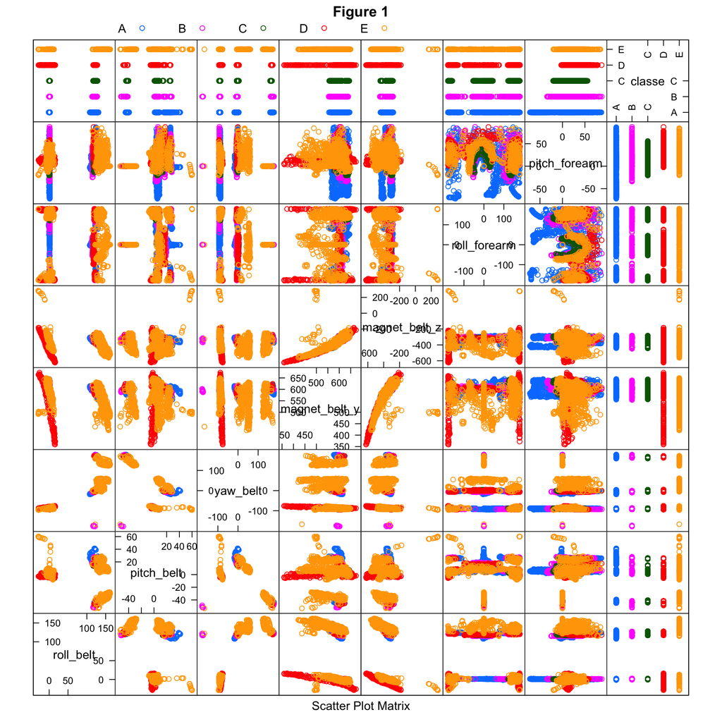

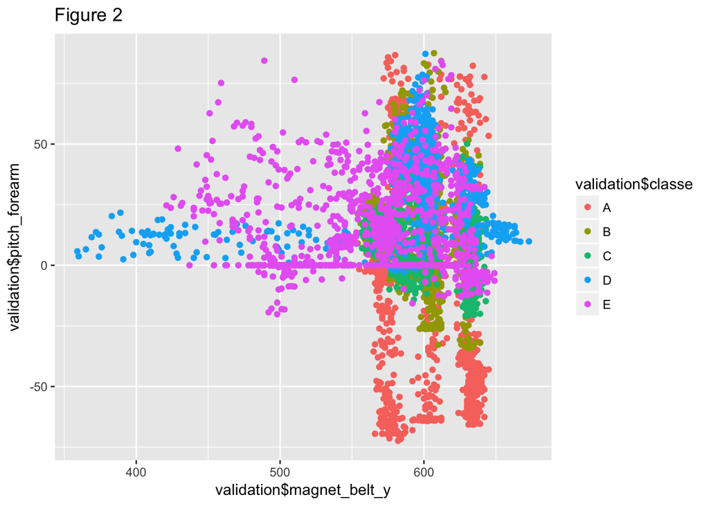

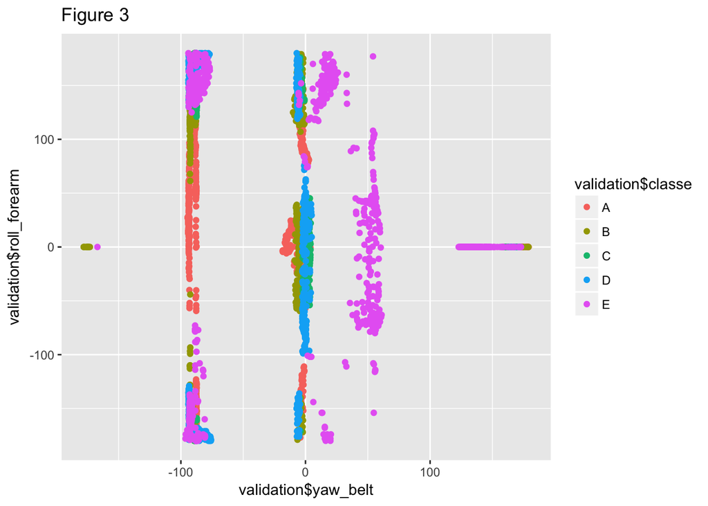

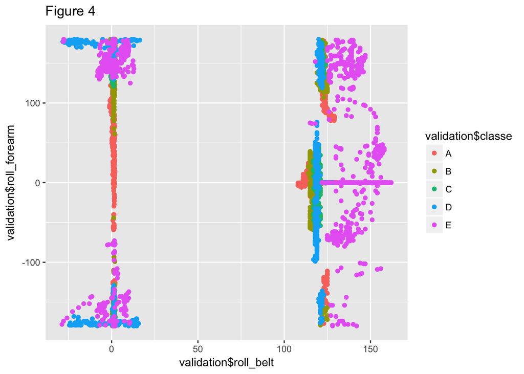